# Exploring univariate patterns

## Getting started

**Directions**

- Open today’s Rmd file linked on the day-to-day schedule. This is where you should take notes. You won’t hand in notes, so do so in whatever way is best for your learning.
- Name and save the file.
- Ignoring past advice, do not knit until the end. The chunks in this Rmd are meant to be run and examined one at a time! In fact, you’ll get an error if you try to knit right away.

**Goals**

- **Statistical Modeling** is the art, science, and design of turning data into information. We’ll start today with **univariate** exploratory analysis. [You can find the slides for today’s preparatory video here.](https://drive.google.com/file/d/198ijb4Zf0pPXZclvof2Sr4aBa7WU5Gbf/view?usp=sharing)
- To learn from data, we need software. Learning how to use software will thus be an important part of this course – without it, we could *learn* about statistics but couldn’t *do* statistics. Our goal will be to do both, starting today.
- Learn about making visualizations using the `ggplot()` function. NOTE: `gg` is short for “grammar of graphics”. The best way to learn about `ggplot()` is to just play around. You can find this handy cheat sheet in the [course manual appendix](https://rstudio.com/wp-content/uploads/2015/03/ggplot2-cheatsheet.pdf).
- Learn about calculating numerical summaries using the `dplyr` package and syntax.
- In the first exercises, you’ll re-construct the plots you saw in today’s videos. You’ll subsequently extend these tools to new variables.

## Exercises

The dataset we will analyze in this assignment comes from Capital Bikeshare, the bike-sharing service for the Washington DC area. The following is the **codebook:**

| variable | meaning |
| --- | --- |
| `date` | date in format YYYY-MM-DD |
| `season` | winter, spring, summer, or fall |
| `year` | 2011 or 2012 |
| `month` | 3-letter month abbreviation |
| `day_of_week` | 3-letter abbreviation for day of week |
| `weekend` | TRUE if the case is a weekend, FALSE otherwise |
| `holiday` | is the day a holiday? (yes or no) |
| `temp_actual` | temperature in degrees Fahrenheit |
| `temp_feel` | what the temperature *feels* like in degrees Fahrenheit |
| `humidity` | fraction from 0 to 1 giving the humidity level |
| `windspeed` | wind speed in miles per hour |
| `weather_cat` | `categ1`: clear to partly cloudy `categ2`: mist + some clouds `categ3`: light precipitation to thunderstorms |
| `riders_casual` | count of daily rides by casual users (non-registered users) |
| `riders_registered` | count of daily rides by registered users |
| `riders_total` | count of total daily rides (`riders_casual + riders_registered`) |

### Exercise 1: Hello!

- Introduce yourselves.
- What other class are you taking this module?
- Who will share their screen (understanding that whoever shares their screen will make mistakes, a necessary part of learning RStudio!)?

### Exercise 2: Import the data

Import the data from Prof Shuman’s website and store it as `bikes`:

https://www.macalester.edu/~dshuman1/data/155/bike_share.csv

NOTE: The original dataset comes from the [UCI Machine Learning Repository](https://archive.ics.uci.edu/ml/datasets/Bike+Sharing+Dataset).

```r
bikes <- read.csv("https://www.macalester.edu/~dshuman1/data/155/bike_share.csv")
"Test to make sure it was imported"
```

```
## [1] "Test to make sure it was imported"
```

```r
dim(bikes)
```

```
## [1] 731  15
```

### Exercise 3: Exploring the data structure

Check out the basic features of the `bikes` data set.

```r
# Examine the first six cases
head(bikes)
```

```
##         date season year month day_of_week weekend holiday temp_actual
## 1 2011-01-01 winter 2011   Jan         Sat    TRUE      no    57.39952
## 2 2011-01-02 winter 2011   Jan         Sun    TRUE      no    58.82468
## 3 2011-01-03 winter 2011   Jan         Mon   FALSE      no    46.49166
## 4 2011-01-04 winter 2011   Jan         Tue   FALSE      no    46.76000
## 5 2011-01-05 winter 2011   Jan         Wed   FALSE      no    48.74943
## 6 2011-01-06 winter 2011   Jan         Thu   FALSE      no    47.08088
##   temp_feel humidity windspeed weather_cat riders_casual riders_registered
## 1  64.72625 0.805833 10.749882      categ2           331               654
## 2  63.83651 0.696087 16.652113      categ2           131               670
## 3  49.04645 0.437273 16.636703      categ1           120              1229
## 4  51.09098 0.590435 10.739832      categ1           108              1454
## 5  52.63430 0.436957 12.522300      categ1            82              1518
## 6  52.98881 0.518261  6.000868      categ1            88              1518
##   riders_total
## 1          985
## 2          801
## 3         1349
## 4         1562
## 5         1600
## 6         1606
```

```r
# Find the dimensions of the data
dim(bikes)
```

```
## [1] 731  15
```

### Exercise 4: Loading a visualization package

To make `ggplot()` visualizations, you need to have the `ggplot2` package loaded in your Rmd:

```r
# Load the ggplot2 package
library(ggplot2)
```

### Exercise 5: Visualizing a categorical variable: bar plots

The `weather_cat` variable is *categorical*. Thus we can visualize its patterns using a **bar plot**. Separately run each chunk below and add a comment (`#`) about what you see. The goal isn’t to memorize the code but to start observing patterns in how the code works.

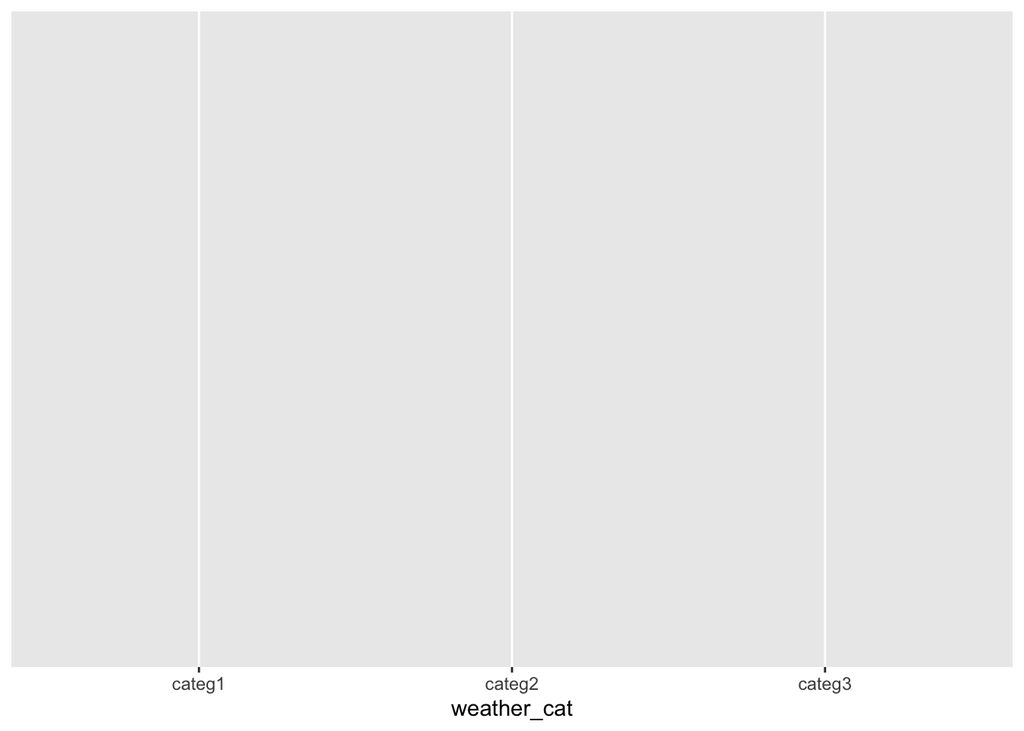

```r
# creates the basic plot, without data?
ggplot(bikes, aes(x = weather_cat))
```

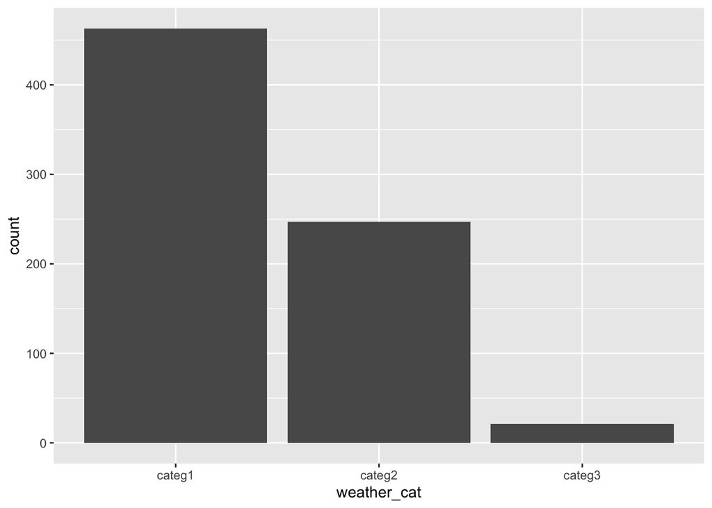

```r
# gives us bar plot of the occurence of each value
ggplot(bikes, aes(x = weather_cat)) +
  geom_bar()
```